# QTM 151 - Quiz 2

## Try to submit as an HTML file

Print your name below

```python
# Write your answer here

print("Azam Lalani")
```

```
Azam Lalani
```

This quiz is open book

- You can use the lecture notes
- You will get partial credit for attempting the questions
- To get full credit, the code should run as intended
- You should NOT communicate with other students

Print the following message:

"I will abide by Emory's code of conduct"

```python
# Write your answer here:

print("I will abide by Emory's code of conduct")
```

```
I will abide by Emory's code of conduct
```

Import the libraries "numpy", "matplotlib.pyplot", and "pandas"

```python
# Write your answer here

import numpy as np
import matplotlib.pyplot as plt
import pandas as pd
```

Import the dataset "data_quiz/fifa23_players_basic.csv"

- It's a dataset on professional soccer players
- Rows correspond to players (18,539)
- Columns contain attributes of players (32)
- Try to view the dataset before starting

```python
# Write your own code

fifa23players = pd.read_csv("data_quiz/fifa23_players_basic.csv")
```

(a) Create a function and apply it to a column

Step 1:

- Define a function with a parameter "year"
- If "year < 2016", status = "Joined before 2016"
- If "height >= 2016", status = "Joined on 2016 or after"
- The function returns "status"

Step 2:

- Extract the column "Joined On" in the dataset

(be carefeful to write the "J" and "O" capitalized)

- Create a new variable called "joined_after2016"

to assign each player to the correct age bracket

HINT: Use the ".apply()" function

```python
# Write your own code

def join2016(year):
    if year < 2016:
        status = "Joined before 2016"
    else:
        status = "Joined on 2016 or after"
    return(status)

fifa23players["joined_After2016"] = fifa23players["Joined On"].apply(join2016)
```

(b) Use queries + global variables

- Compute the mean of the column "Height(in cm)"

and store it as a variable

- Subset the players whose value is above the mean value  
  using ".query()"

HINT: Remember that there is a special syntax for  
when the column names have spaces (see Lecture 10)  
Reference the column as `` `Height(in cm)` `` inside .query()

```python
# Write your own code

meanheight = fifa23players["Height(in cm)"].mean()

abovemean = fifa23players.query("`Height(in cm)` > @meanheight")

display(abovemean)
```

|  | Known As | Full Name | Overall | Potential | Value(in Euro) | Positions Played | Best Position | Nationality | Image Link | Age | ... | Weak Foot Rating | Skill Moves | International Reputation | National Team Name | National Team Image Link | National Team Position | National Team Jersey Number | Attacking Work Rate | Defensive Work Rate | joined_After2016 |
| --- | --- | --- | --- | --- | --- | --- | --- | --- | --- | --- | --- | --- | --- | --- | --- | --- | --- | --- | --- | --- | --- |
| 1 | K. Benzema | Karim Benzema | 91 | 91 | 64000000 | CF,ST | CF | France | https://cdn.sofifa.net/players/165/153/23_60.png | 34 | ... | 4 | 4 | 4 | France | https://cdn.sofifa.net/flags/fr.png | ST | 19 | Medium | Medium | Joined before 2016 |
| 2 | R. Lewandowski | Robert Lewandowski | 91 | 91 | 84000000 | ST | ST | Poland | https://cdn.sofifa.net/players/188/545/23_60.png | 33 | ... | 4 | 4 | 5 | Poland | https://cdn.sofifa.net/flags/pl.png | ST | 9 | High | Medium | Joined on 2016 or after |
| 4 | K. Mbappé | Kylian Mbappé | 91 | 95 | 190500000 | ST,LW | ST | France | https://cdn.sofifa.net/players/231/747/23_60.png | 23 | ... | 4 | 5 | 4 | France | https://cdn.sofifa.net/flags/fr.png | ST | 10 | High | Low | Joined on 2016 or after |
| 6 | T. Courtois | Thibaut Courtois | 90 | 91 | 90000000 | GK | GK | Belgium | https://cdn.sofifa.net/players/192/119/23_60.png | 30 | ... | 3 | 1 | 4 | Belgium | https://cdn.sofifa.net/flags/be.png | GK | 1 | Medium | Medium | Joined on 2016 or after |
| 7 | M. Neuer | Manuel Neuer | 90 | 90 | 13500000 | GK | GK | Germany | https://cdn.sofifa.net/players/167/495/23_60.png | 36 | ... | 4 | 1 | 5 | Germany | https://cdn.sofifa.net/flags/de.png | GK | 1 | Medium | Medium | Joined before 2016 |
| ... | ... | ... | ... | ... | ... | ... | ... | ... | ... | ... | ... | ... | ... | ... | ... | ... | ... | ... | ... | ... | ... |
| 18520 | N. Deka | Nikhil Deka | 48 | 61 | 100000 | GK | GK | India | https://cdn.sofifa.net/players/261/423/23_60.png | 19 | ... | 3 | 1 | 1 | - | - | - | - | Medium | Medium | Joined on 2016 or after |
| 18521 | V. Yadav | Vishal Yadav | 48 | 62 | 100000 | GK | GK | India | https://cdn.sofifa.net/players/259/488/23_60.png | 20 | ... | 3 | 1 | 1 | - | - | - | - | Medium | Medium | Joined on 2016 or after |
| 18524 | A. Brînzea | Andreș Brînzea | 48 | 72 | 130000 | GK | GK | Romania | https://cdn.sofifa.net/players/271/179/23_60.png | 16 | ... | 2 | 1 | 1 | - | https://cdn.sofifa.net/flags/ro.png | - | - | Medium | Medium | Joined on 2016 or after |
| 18525 | J. Russell-Rowe | Jacen Russell-Rowe | 48 | 65 | 120000 | ST | CAM | Canada | https://cdn.sofifa.net/players/269/923/23_60.png | 19 | ... | 3 | 2 | 1 | - | https://cdn.sofifa.net/flags/ca.png | - | - | Medium | Medium | Joined on 2016 or after |
| 18528 | Zhang Yue | Yue Zhang | 48 | 56 | 110000 | RM | LM | China PR | https://cdn.sofifa.net/players/268/922/23_60.png | 22 | ... | 2 | 2 | 1 | - | - | - | - | Medium | Medium | Joined on 2016 or after |

9352 rows × 33 columns

(c) Use sorting + ".iloc[]"

- Use ".sort_values()" to order the "Value(in Euro)" column

from largest to smaller

- Get a subset with the 5 players with the highest monetary valuation

```python
# Write your own code

playermoney = fifa23players.sort_values(by = "Value(in Euro)", ascending = False)

display(playermoney)

top5money = playermoney.iloc[0:5,:]

display(top5money)
```

|  | Known As | Full Name | Overall | Potential | Value(in Euro) | Positions Played | Best Position | Nationality | Image Link | Age | ... | Weak Foot Rating | Skill Moves | International Reputation | National Team Name | National Team Image Link | National Team Position | National Team Jersey Number | Attacking Work Rate | Defensive Work Rate | joined_After2016 |
| --- | --- | --- | --- | --- | --- | --- | --- | --- | --- | --- | --- | --- | --- | --- | --- | --- | --- | --- | --- | --- | --- |
| 4 | K. Mbappé | Kylian Mbappé | 91 | 95 | 190500000 | ST,LW | ST | France | https://cdn.sofifa.net/players/231/747/23_60.png | 23 | ... | 4 | 5 | 4 | France | https://cdn.sofifa.net/flags/fr.png | ST | 10 | High | Low | Joined on 2016 or after |
| 21 | E. Haaland | Erling Haaland | 88 | 94 | 148000000 | ST | ST | Norway | https://cdn.sofifa.net/players/239/085/23_60.png | 21 | ... | 3 | 3 | 4 | Norway | https://cdn.sofifa.net/flags/no.png | ST | 9 | High | Medium | Joined on 2016 or after |
| 42 | F. de Jong | Frenkie de Jong | 87 | 92 | 116500000 | CM | CM | Netherlands | https://cdn.sofifa.net/players/228/702/23_60.png | 25 | ... | 3 | 4 | 3 | Netherlands | https://cdn.sofifa.net/flags/nl.png | CDM | 21 | High | Medium | Joined on 2016 or after |
| 82 | Pedri | Pedro González López | 85 | 93 | 116000000 | CM | CM | Spain | https://cdn.sofifa.net/players/251/854/23_60.png | 19 | ... | 4 | 4 | 2 | Spain | https://cdn.sofifa.net/flags/es.png | CM | 10 | High | High | Joined on 2016 or after |
| 5 | M. Salah | Mohamed Salah | 90 | 90 | 115500000 | RW | RW | Egypt | https://cdn.sofifa.net/players/209/331/23_60.png | 30 | ... | 3 | 4 | 4 | - | - | - | - | High | Medium | Joined on 2016 or after |
| ... | ... | ... | ... | ... | ... | ... | ... | ... | ... | ... | ... | ... | ... | ... | ... | ... | ... | ... | ... | ... | ... |
| 896 | A. Vega | Alexis Vega | 77 | 83 | 0 | LW,ST,LM | CAM | Mexico | https://cdn.sofifa.net/players/233/260/23_60.png | 24 | ... | 3 | 3 | 1 | Mexico | https://cdn.sofifa.net/flags/mx.png | SUB | 10 | Medium | Low | Joined on 2016 or after |
| 9453 | N. Alho | Nikolai Alho | 66 | 66 | 0 | RB,RWB,RM | RB | Finland | https://cdn.sofifa.net/players/234/298/23_60.png | 29 | ... | 3 | 3 | 1 | Finland | https://cdn.sofifa.net/flags/fi.png | RWB | 17 | Medium | Medium | Joined on 2016 or after |
| 865 | M. Borjan | Milan Borjan | 77 | 77 | 0 | GK | GK | Canada | https://cdn.sofifa.net/players/205/211/23_60.png | 34 | ... | 2 | 1 | 1 | Canada | https://cdn.sofifa.net/flags/ca.png | GK | 18 | Medium | Medium | Joined on 2016 or after |
| 831 | D. Lovren | Dejan Lovren | 78 | 78 | 0 | CB | CB | Croatia | https://cdn.sofifa.net/players/195/086/23_60.png | 32 | ... | 4 | 2 | 2 | Croatia | https://cdn.sofifa.net/flags/hr.png | CB | 6 | Medium | High | Joined on 2016 or after |
| 9901 | M. Barsham | Meshaal Barsham | 65 | 71 | 0 | GK | GK | Qatar | https://cdn.sofifa.net/players/268/783/23_60.png | 24 | ... | 3 | 1 | 1 | Qatar | https://cdn.sofifa.net/flags/qa.png | SUB | 22 | Medium | Medium | Joined on 2016 or after |

18539 rows × 33 columns

|  | Known As | Full Name | Overall | Potential | Value(in Euro) | Positions Played | Best Position | Nationality | Image Link | Age | ... | Weak Foot Rating | Skill Moves | International Reputation | National Team Name | National Team Image Link | National Team Position | National Team Jersey Number | Attacking Work Rate | Defensive Work Rate | joined_After2016 |
| --- | --- | --- | --- | --- | --- | --- | --- | --- | --- | --- | --- | --- | --- | --- | --- | --- | --- | --- | --- | --- | --- |
| 4 | K. Mbappé | Kylian Mbappé | 91 | 95 | 190500000 | ST,LW | ST | France | https://cdn.sofifa.net/players/231/747/23_60.png | 23 | ... | 4 | 5 | 4 | France | https://cdn.sofifa.net/flags/fr.png | ST | 10 | High | Low | Joined on 2016 or after |
| 21 | E. Haaland | Erling Haaland | 88 | 94 | 148000000 | ST | ST | Norway | https://cdn.sofifa.net/players/239/085/23_60.png | 21 | ... | 3 | 3 | 4 | Norway | https://cdn.sofifa.net/flags/no.png | ST | 9 | High | Medium | Joined on 2016 or after |
| 42 | F. de Jong | Frenkie de Jong | 87 | 92 | 116500000 | CM | CM | Netherlands | https://cdn.sofifa.net/players/228/702/23_60.png | 25 | ... | 3 | 4 | 3 | Netherlands | https://cdn.sofifa.net/flags/nl.png | CDM | 21 | High | Medium | Joined on 2016 or after |
| 82 | Pedri | Pedro González López | 85 | 93 | 116000000 | CM | CM | Spain | https://cdn.sofifa.net/players/251/854/23_60.png | 19 | ... | 4 | 4 | 2 | Spain | https://cdn.sofifa.net/flags/es.png | CM | 10 | High | High | Joined on 2016 or after |
| 5 | M. Salah | Mohamed Salah | 90 | 90 | 115500000 | RW | RW | Egypt | https://cdn.sofifa.net/players/209/331/23_60.png | 30 | ... | 3 | 4 | 4 | - | - | - | - | High | Medium | Joined on 2016 or after |

5 rows × 33 columns

(d) Create a function with four inputs $f(y,x,b0,b1)$

$\qquad e2 = (y - b_0 - b_1 * x)^2$

- The function should return the sum of e2 entries
- This is the residual sum of squares (rss)
- Call the function "fn_rss"
- Let $y$ be the column "Overall" (overall score)
- Let $x$ be the column "Age"
- Does

$\qquad (b_0 = 50, b_1 = -6 )$ or  
$\qquad (b_0 = 50, b_1 = 0.6 )$ or  
$\qquad (b_0 = 50, b_1 = 6)$  
produce the lowest value of rss?

```python
# Write your own code

fn_rss =  lambda y,b0,b1,x: sum((y-b0-(b1*x))**2)

print(fn_rss(fifa23players["Overall"],50,-6,fifa23players["Age"]))
print(fn_rss(fifa23players["Overall"],50,0.6,fifa23players["Age"]))
print(fn_rss(fifa23players["Overall"],50,6,fifa23players["Age"]))

#(b0 = 50, b1 = 0.6) produces the lowest value of rss
```

```
537721853
696928.5200000058
353393885
```

(e) Split a dataset into subsets

- Create `list_status = [1,2]`
- Create `list_prob = [0.5, 0.5]`
- Create a new variable $n$ with the number of rows of the dataset
- Use

```
np.random.choice(list_status,
                     size = n,
                     p = list_prob)
```

$\qquad$ to create a new column called "status"  
$\qquad$ which randomly assigns each row to "1" or "2"  
$\qquad$ with equal probability

- Use .query() to subset all observations with status == 1.

store it in a new dataset called "data1"

- Use .query() to subset all observations with status == 2.

store it in a new dataset called "data2"

```python
# Write your own code

list_status = [1,2]
list_prob = [0.5,0.5]
n = len(fifa23players)

fifa23players["status"] = np.random.choice(list_status,size = n, p = list_prob)

data1 = fifa23players.query('status == 1')
data2 = fifa23players.query('status == 2')
```

(f) Create two overlapping histogram plots

- This function requires the two datasets you created in (e)
- Display the distribution of "Potential" for "data1" and "data2"
- Use the "alpha" option to make the graphs semitransparent
- You will need to add a legend, label the axes, and the title

Note: The goal of this question is to illustrate that random  
assignment produces very similar distributions between two groups

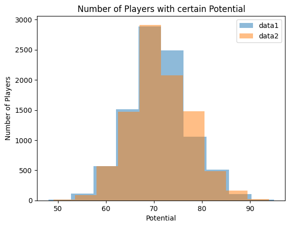

```python
# Write your own code

list_data = [data1, data2]

for data in list_data:
    df = data
    plt.hist(x = df["Potential"],alpha = 0.5)
plt.xlabel("Potential")
plt.ylabel("Number of Players")
plt.legend(labels = ["data1","data2"])
plt.title("Number of Players with certain Potential")
plt.show()

#The distributions are very similar, attesting to the validity of the random assignment concept
```